# Analysis of Zillow data

Arkajyoti Saha

15 September 2017

As we are only a month away from the final submission date for the first round of Zillow competition, I do feel that it is pretty hard to get excited about a priliminary level analysis at this point of time, that too in presence of a number of enriching kernels on the very same topic. This is nothing but a humble attempt of a beginner at data scince to get constructive feedbacks from the fellow kagglers.

```r
library(data.table)
library(dplyr)
library(ggplot2)
library(tidyr)
library(corrplot)
```

The primary task in the competition is to predict the log error in Zillow’s estimation of property value (“Zestimate”). The data is subdivided into two parts, the first one being the information on the home features of the properties, the second one being the set of available responses. Detailed information on these datasets can be found in the competition website. First we read the data:

```r
# Load data
properties <- fread('properties_2016.csv')
train_data <- fread('train_2016_v2.csv')
```

Some of the feature names in the properties dataset donot clearly represent what they actually mean. For sake of clarity, we rename a few of them as follows:

```r
# Renaming of features with confusing names
properties <- properties %>% rename(
  patio_yard = yardbuildingsqft17,
  storage_yard = yardbuildingsqft26,
  base_unfin_fin = finishedsquarefeet6,
  liv_area_fin = finishedsquarefeet12,
  liv_peri_fin = finishedsquarefeet13,
  total_fin = finishedsquarefeet15,
  liv_fin_1st = finishedsquarefeet50
)
```

In this EDA, we will primarily be interested in the set of points, for which the log error response are available, i.e. the parcelid’s in the training dataset.

```r
# Joining with respect to parcelids
setkey(properties, parcelid)
setkey(train_data, parcelid)

merged_data <- properties[train_data]

rm(properties, train_data)
```

In the provided dataset, for a number of variables, most of the data are missing, which becomes evident from the following figure:

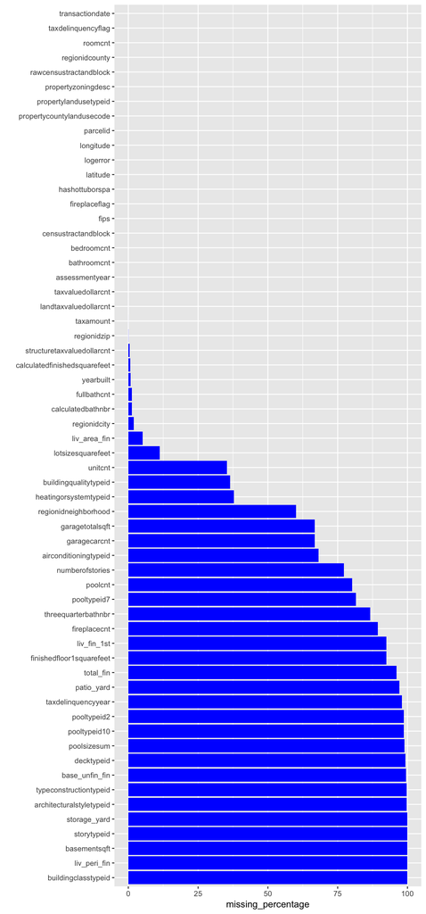

```r
# Analysis of missing data
missing_values <- merged_data %>% summarise_all(funs(sum(is.na(.))/n() * 100))

missing_values <- gather(missing_values, key="Variable", value="missing_percentage")

missing_values %>%
  ggplot(aes(x=reorder(Variable,-missing_percentage),y = missing_percentage)) +
  geom_bar(stat="identity",fill="blue")+ labs(x = '')+
  coord_flip()
```

One of the most common ways to handle missing data is through data imputation. For a variable with it’s most of the data missing, data imputation may not only fail to provide additional information, but also worsen the performance of the estimation. If we look closely at the figure above, clearly there are a number of variables with more than 50% of missing data. For here on we proceed with the features having less than 50% of missing data, to further explore the correlation structure between the features.

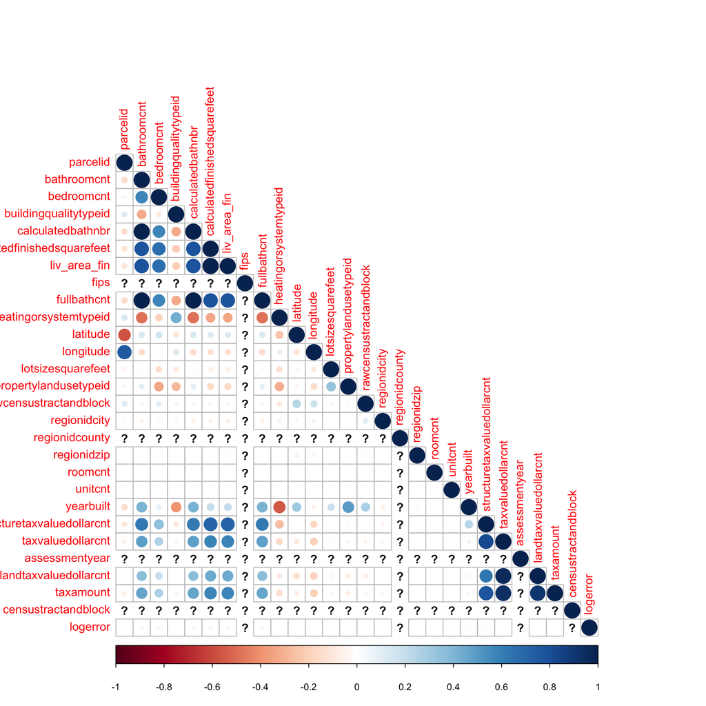

```r
#Variable Selection
good_variables_50 <- filter(missing_values, missing_percentage< 50)

avl_variable <- good_variables_50$Variable
num_avl_variable <- avl_variable[sapply(avl_variable, function(x) is.numeric(merged_data[[x]]))]
cor_plot <- merged_data %>% select(one_of(c(num_avl_variable,"logerror")))
correlation_structure <- cor(cor_plot, use="complete.obs")
corrplot(correlation_structure,type="lower")
```

In the figure above we observe that the log error is not correlated with any of the home features. Moreover, there are few groups of highly correlated features. In order to explore the interesting pairs of highly correlated features, we find out the variable pairs having correlation with absolute value more than 0.75.

```r
correlation_structure_no_diag = correlation_structure - diag(rep(1,each = dim(correlation_structure)[1]))
result <- which(abs(correlation_structure_no_diag) > 0.75, arr.ind = TRUE)
result
```

```
##                              row col
## longitude                     12   1
## calculatedbathnbr              5   2
## calculatedfinishedsquarefeet   6   2
## liv_area_fin                   7   2
## fullbathcnt                    9   2
## bathroomcnt                    2   5
## calculatedfinishedsquarefeet   6   5
## liv_area_fin                   7   5
## fullbathcnt                    9   5
## bathroomcnt                    2   6
## calculatedbathnbr              5   6
## liv_area_fin                   7   6
## fullbathcnt                    9   6
## bathroomcnt                    2   7
## calculatedbathnbr              5   7
## calculatedfinishedsquarefeet   6   7
## fullbathcnt                    9   7
## bathroomcnt                    2   9
## calculatedbathnbr              5   9
## calculatedfinishedsquarefeet   6   9
## liv_area_fin                   7   9
## parcelid                       1  12
## taxvaluedollarcnt             23  22
## taxamount                     26  22
## structuretaxvaluedollarcnt    22  23
## landtaxvaluedollarcnt         25  23
## taxamount                     26  23
## taxvaluedollarcnt             23  25
## taxamount                     26  25
## structuretaxvaluedollarcnt    22  26
## taxvaluedollarcnt             23  26
## landtaxvaluedollarcnt         25  26
```

Next, we draw the scatter plot of a pair of these highly correlated features to actually demonstrate how they really look like:

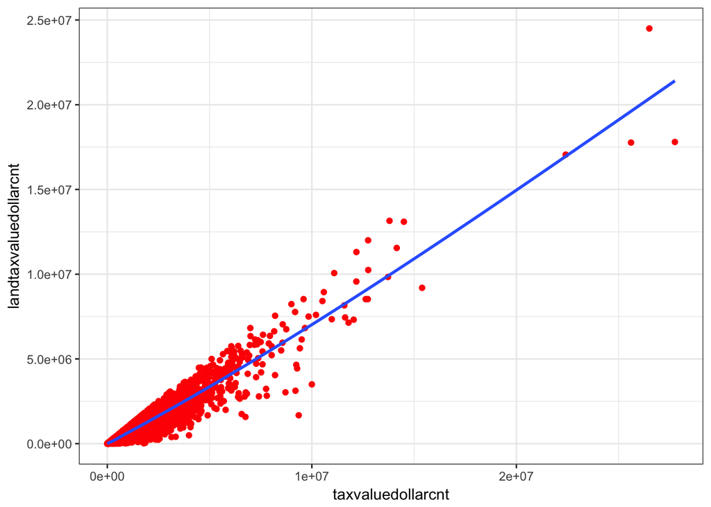

```r
i <- 28
ggplot(cor_plot, aes(x = cor_plot[[result[i,1]]], y = cor_plot[[result[i,2]]])) +
  geom_point(color="red") +
  geom_smooth() + labs(x = names(cor_plot)[result[i,1]], y = names(cor_plot)[result[i,2]]) +
  theme_bw()
```

The detailed EDA kernels on Zillow by Philipp Spachtholz and Troy Walters have immensely helped me to get started with the data analysis on this. Though late, I am only getting started with the data analysis and plan to add a lot more very soon. Please do check back and any feedback is welcome!